# Pràctica 2: Neteja i validació de les dades

Víctor Espinosa Yxart

30 de desembre de 2018

# 1 Descripció del dataset.

Treballarem amb el dataset que vam generar a la pràctica 1 amb les companyies més importants de la llista Fortune.

Aquest dataset és interessant, ja que ens dóna una visió de quines són les companyies més importants dels EUA i de les seves característiques.

Analitzant aquest conjunt de dades intentarem estudiar quins són els sectors dominants i la diferència entre el nombre d’homes i dones que ocupen càrrecs directius.

El dataset original es troba al següent repositori: https://github.com/victor427/PRAC1-Web-Scraping

# 2 Neteja de les dades.

## 2.1 Carregar el fitxer

Amb aquesta informació podem fer servir la funció *read.csv* per llegir el fitxer i transformar-lo en dades estructurades.

```r
inputFile <- "./PRAC1-Web-Scraping-master/data/fortune500.csv"

writeLines(readLines(inputFile, n = 5))
```

```
## rank;title;revenue;ceo;position;sector;industry;hq;website;years;employees;image;
## 1;Walmart;$500,343;C. Douglas McMillon;President, Chief Executive Officer & Director;Retailing;General Merchandisers;Bentonville, Ark.;www.stock.walmart.com;24;2,300,000;walmart-fortune-5001;
## 2;Exxon Mobil;$244,363;Darren W. Woods;Chairman & Chief Executive Officer;Energy;Petroleum Refining;Irving, Texas;www.exxonmobil.com;24;71,200;exxonmobil-fortune-500;
## 3;Berkshire Hathaway;$242,137;Warren E. Buffett;Chairman, President & Chief Executive Officer;Financials;Insurance: Property and Casualty (Stock);Omaha;www.berkshirehathaway.com;24;377,000;berkshire-hathaway-fortune-5001;
## 4;Apple;$229,234;Timothy D. Cook;Chairman & Chief Executive Officer;Technology;Computers, Office Equipment;Cupertino, Calif.;www.apple.com;24;123,000;apple-fortune-500;
```

```r
f500 <- read.csv(inputFile, header = TRUE, sep = ";", quote = "\"", dec = ".")
```

## 2.2 Identificar les variables

Aquestes són les diferents variables que tenim a les nostres dades i el seu tipus.

- **rank** $\rightarrow$ Quantitativa discreta
- **title** $\rightarrow$ Qualitativa nominal
- **revenue** $\rightarrow$ Quantitativa contínua
- **ceo** $\rightarrow$ Qualitativa nominal
- **position** $\rightarrow$ Qualitativa nominal
- **sector** $\rightarrow$ Qualitativa nominal
- **industry** $\rightarrow$ Qualitativa nominal
- **hq** $\rightarrow$ Qualitativa nominal
- **website** $\rightarrow$ Qualitativa nominal
- **years** $\rightarrow$ Quantitativa discreta
- **employees** $\rightarrow$ Quantitativa discreta
- **image** $\rightarrow$ Qualitativa nominal

## 2.3 Corretgir el tipus de variables

Per saber quin tipus hi ha assignat R a cada variable podem fer servir la funció class sobre el conjunt de dades. Si s’ha identificat erròniament alguna variable definirem manualment el tipus que volem.

```r
lapply(f500, class)
```

```
## $rank
## [1] "integer"
##
## $title
## [1] "factor"
##
## $revenue
## [1] "factor"
##
## $ceo
## [1] "factor"
##
## $position
## [1] "factor"
##
## $sector
## [1] "factor"
##
## $industry
## [1] "factor"
##
## $hq
## [1] "factor"
##
## $website
## [1] "factor"
##
## $years
## [1] "factor"
##
## $employees
## [1] "factor"
##
## $image
## [1] "factor"
##
## $X
## [1] "logical"
```

```r
f500[13] <- NULL

f500$revenue <- gsub('[$]','',f500$revenue)
f500$revenue <- gsub('[,]','',f500$revenue)

f500$rank      <- as.integer(f500$rank)
f500$title     <- as.factor(f500$title)
f500$revenue   <- as.numeric(f500$revenue)
f500$ceo       <- as.factor(f500$ceo)
f500$position  <- as.factor(f500$position)
f500$sector    <- as.factor(f500$sector)
f500$industry  <- as.factor(f500$industry)
f500$hq        <- as.factor(f500$hq)
f500$website   <- as.factor(f500$website)
f500$years     <- as.integer(f500$years)
f500$employees <- as.integer(f500$employees)
f500$image     <- as.factor(f500$image)

lapply(f500, class)
```

```
## $rank
## [1] "integer"
##
## $title
## [1] "factor"
##
## $revenue
## [1] "numeric"
##
## $ceo
## [1] "factor"
##
## $position
## [1] "factor"
##
## $sector
## [1] "factor"
##
## $industry
## [1] "factor"
##
## $hq
## [1] "factor"
##
## $website
## [1] "factor"
##
## $years
## [1] "integer"
##
## $employees
## [1] "integer"
##
## $image
## [1] "factor"
```

## 2.4 Búsqueda de valors atípics

Fem un boxplot per les variables quantitatives i observem si existeixen outliers

En aquest cas els outliers de la variable revenue són dades coherents, i per la variable employees no hem trobat cap valor atípic.

### 2.4.1 Boxplots de les variables quantitatives

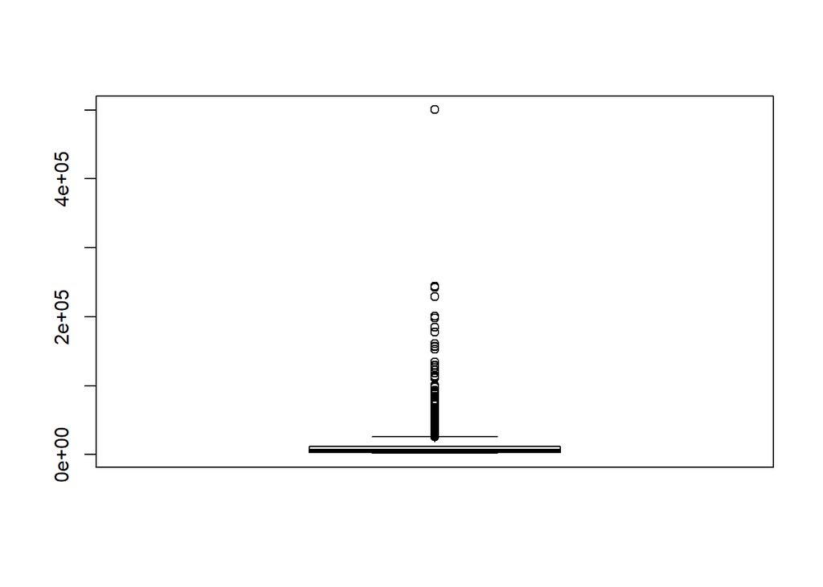

```r
boxplot(f500$revenue)
```

```r
boxplot.stats(f500$revenue)$out
```

```
##   [1] 500343.0 244363.0 242137.0 229234.0 201159.0 198533.0 184765.0
##   [8] 177866.0 160546.0 157311.0 156776.0 153144.0 134533.0 129976.0
##  [15] 129025.0 126034.0 122662.0 122274.0 118214.0 113899.0 112394.0
##  [22] 110855.0 100904.0 100264.0 100064.6  97741.0  93392.0  91568.0
##  [29]  90039.4  89950.0  88407.0  87966.0  84526.0  79139.0  78660.0
##  [36]  78330.8  76450.0  74676.0  71879.0  68619.0  67610.0  66217.0
##  [43]  66153.0  65872.0  63525.0  62761.0  62683.0  60828.0  60535.0
##  [50]  60319.0  59837.0  59689.0  59678.2  55371.1  55137.0  53767.0
##  [57]  52546.0  52056.0  51048.0  49520.0  48572.0  48005.0  47653.0
##  [64]  47487.0  45462.0  43939.9  43642.0  42687.0  42296.0  42254.0
##  [71]  42207.0  42151.0  41616.0  41581.0  41244.0  40653.0  40534.0
##  [78]  40122.0  38524.0  38260.0  37736.0  37728.0  36775.0  36025.3
##  [85]  35864.7  35583.0  35410.0  34836.8  34350.0  34204.0  33695.5
##  [92]  33531.0  33495.4  32845.1  32584.0  31934.8  31657.0  31271.0
##  [99]  30973.0  30015.8  29999.0  29737.7  29423.6  29331.0  29241.5
## [106]  28902.0  28871.0  28748.0  28500.0  28216.0  27390.0  26839.0
## [113]  26812.5  26232.0  26223.0  26107.0
```

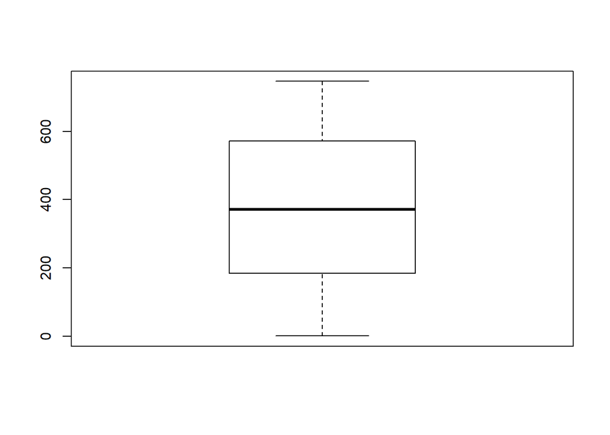

```r
boxplot(f500$employees)
```

```r
boxplot.stats(f500$employees)$out
```

```
## integer(0)
```

## 2.5 Valors perduts

S’han trobat valors perduts en les variables ceo, position, industry, hq, website, years, employees i image.

Després s’han torbat 14 registres que estan incomplets i depenent de les observacions que estem fent sobre el dataset haurem de tenir present treure aquestes dades.

```r
sapply(f500, function(x) sum(is.na(x)))
```

```
##      rank     title   revenue       ceo  position    sector  industry
##         0         0         0        14        14         0        14
##        hq   website     years employees     image
##        14        14        14        14       508
```